# Hands-on Exercise 10

“In this hands-on exercise, I will learn to how to calibrate Spatial Interaction Models (SIM) by using GLM() of Base R. The use case is adapted from Modelling population flows using spatial interaction models by Adam Dennett.”

Niharika Avula https://example.com/norajones  
2021-10-26

# 1. Overview

By the end to this hands-on exercise, the following will be covered:

- to import GIS polygon data into R and save them as simple feature data.frame and SpatialPolygonsDataFrame by using appropriate functions of sf package of R
- to compute distance matrix in R
- to import aspatial data into R and save it as a data.frame
- to integrate the imported data.frame with the distance matrix
- to calibrate Spatial Interaction Models by using glm() of R
- to assess the perfromance of the SIMs by computing Goodness-of-Fit statistics

# 2. Getting Started

## 2.1 The data

Two data sets will be used in this hands-on exercise, they are:

- [Greater Capital City Statistical Areas, Australia](https://www.abs.gov.au/websitedbs/censushome.nsf/home/factsheetsgeography/$file/Greater%20Capital%20City%20Statistical%20Area%20-%20Fact%20Sheet.pdf) . It is in geojson format.
- [Migration data from 2011 Australia Census](https://www.abs.gov.au/ausstats/abs@.nsf/ViewContent?readform&view=productsbytopic&Action=Expand&Num=5.5.5). It is in csv file format.

In the later sections, it will be shown how to fetch these data directly from their hosting repositories online.

## 2.2 Installing and loading R packages

The R packages needed for this exercise are as follows:

- **Spatial data handling:** sf, sp, geojsonio, stplanr
- **Attribute data handling:** tidyverse, especially readr and dplyr, reshape2,
- **Thematic mapping:** tmap
- **Statistical graphic:** ggplot2
- **Statistical analysis:** caret

```r
packages = c('tmap', 'tidyverse',
             'sp', 'caret','sf',
             'geojsonio', 'reshape2',
             'broom','rgdal')

for(p in packages){
  if(!require(p, character.only = T)){
    install.packages(p)
  }
  library(p, character.only = T)
}
```

Due to s2 object class issue, we will use the order version (i.e. 0.9-8) of sf package instead of the latest version (i.e. 1.0-3). The code chunk below will be used the install the appropriate version.

```r
library(devtools)
install_version("sf", version= "0.9-8", repos= "http://cran.us.r-project.org")
```

```
e1071 (1.7-8 -> 1.7-9) [CRAN]
```

```r
library(sf)
```

# 3. Data Import and Prepatation

## 3.1 Importing geospatial data into R environment

Downloading a copy of the Greater Capital City Statistical Areas boundary layer from a dropbox depository using geojson_read() of geojsonio package.

```r
Aus <- geojson_read("https://www.dropbox.com/s/0fg80nzcxcsybii/GCCSA_2016_AUST_New.geojson?raw=1", what = "sp")
```

Next, extract the data by using the code chunk below

```r
Ausdata <- Aus@data
```

## 3.2 Convert to sf object and set CRS

The original data is in geojson format which needs to be converted into a ‘simple features’ object and set the coordinate reference system at the same time in case the file doesn’t have one.

```r
AusSF <- st_as_sf(Aus) %>%
  st_set_crs(4283)
```

## 3.3 Check and fix validity of simple features

Next, check if all the simple features are valid by using the code chunk below.

```r
st_is_valid(AusSF)
```

```
 [1]  TRUE FALSE  TRUE  TRUE  TRUE  TRUE  TRUE  TRUE  TRUE  TRUE  TRUE
[12] FALSE  TRUE  TRUE  TRUE
```

The output shows that there are several invalid features which needs to be fixed

```r
st_make_valid(AusSF)
```

```
Simple feature collection with 15 features and 6 fields
Geometry type: MULTIPOLYGON
Dimension:     XY
Bounding box:  xmin: 112.9211 ymin: -43.74051 xmax: 159.1092 ymax: -9.142176
Geodetic CRS:  GDA94
First 10 features:
   GCCSA_CODE GCC_CODE16        GCCSA_NAME STATE_CODE
1       1RNSW      1RNSW       Rest of NSW          1
2       1GSYD      1GSYD    Greater Sydney          1
3       2GMEL      2GMEL Greater Melbourne          2
4       2RVIC      2RVIC      Rest of Vic.          2
5       3RQLD      3RQLD       Rest of Qld          3
6       3GBRI      3GBRI  Greater Brisbane          3
7       4RSAU      4RSAU        Rest of SA          4
8       4GADE      4GADE  Greater Adelaide          4
9       5GPER      5GPER     Greater Perth          5
10      5RWAU      5RWAU        Rest of WA          5
          STATE_NAME   AREA_SQKM                       geometry
1    New South Wales  788442.589 MULTIPOLYGON (((159.0611 -3...
2    New South Wales   12368.193 MULTIPOLYGON (((151.266 -33...
3           Victoria    9992.512 MULTIPOLYGON (((144.9065 -3...
4           Victoria  217503.119 MULTIPOLYGON (((146.6858 -3...
5         Queensland 1714330.123 MULTIPOLYGON (((150.7377 -2...
6         Queensland   15841.960 MULTIPOLYGON (((153.3738 -2...
7    South Australia  981015.072 MULTIPOLYGON (((136.1844 -3...
8    South Australia    3259.836 MULTIPOLYGON (((138.5269 -3...
9  Western Australia    6416.222 MULTIPOLYGON (((115.7132 -3...
10 Western Australia 2520230.017 MULTIPOLYGON (((117.896 -35...
```

```r
st_is_valid(AusSF)
```

```
 [1]  TRUE FALSE  TRUE  TRUE  TRUE  TRUE  TRUE  TRUE  TRUE  TRUE  TRUE
[12] FALSE  TRUE  TRUE  TRUE
```

## 3.4 Displaying boundary layer

It is good practice to plot the data and check if the boundary layer is correct. The code chunk below is used to plot AusSF simple feature data.frame by using qtm() of tmap package.

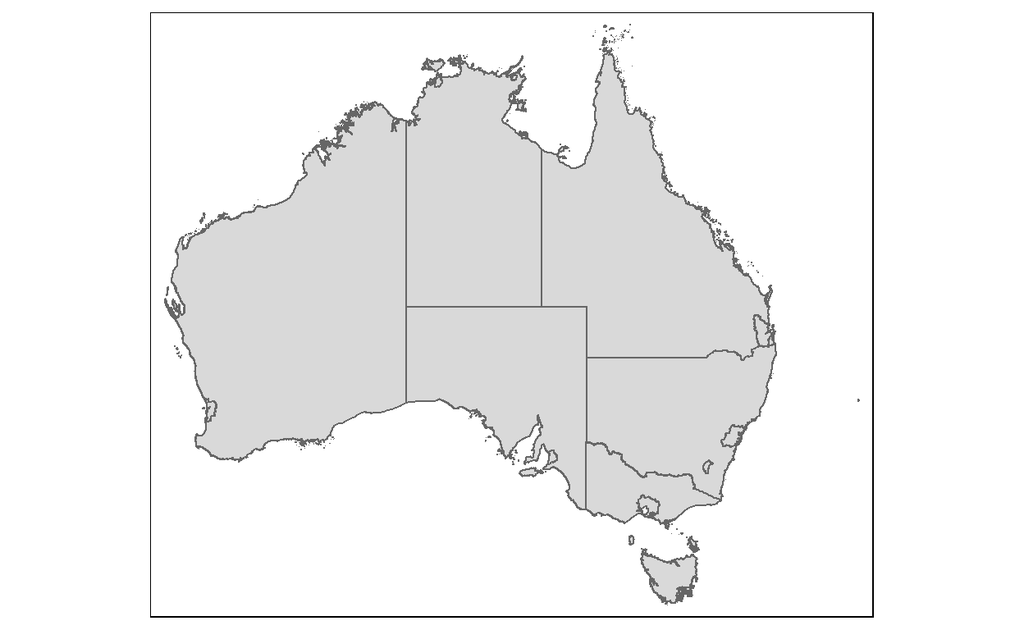

```r
tmap_mode("plot")
tmap_options(check.and.fix = TRUE)
qtm(AusSF)
```

## 3.5 Displaying data table

Viewing the simple feature data.frame by using the code chunk below

```r
head(AusSF, 10)
```

```
Simple feature collection with 10 features and 6 fields
Geometry type: MULTIPOLYGON
Dimension:     XY
Bounding box:  xmin: 112.9211 ymin: -39.15919 xmax: 159.1092 ymax: -9.142176
Geodetic CRS:  GDA94
   GCCSA_CODE GCC_CODE16        GCCSA_NAME STATE_CODE
1       1RNSW      1RNSW       Rest of NSW          1
2       1GSYD      1GSYD    Greater Sydney          1
3       2GMEL      2GMEL Greater Melbourne          2
4       2RVIC      2RVIC      Rest of Vic.          2
5       3RQLD      3RQLD       Rest of Qld          3
6       3GBRI      3GBRI  Greater Brisbane          3
7       4RSAU      4RSAU        Rest of SA          4
8       4GADE      4GADE  Greater Adelaide          4
9       5GPER      5GPER     Greater Perth          5
10      5RWAU      5RWAU        Rest of WA          5
          STATE_NAME   AREA_SQKM                       geometry
1    New South Wales  788442.589 MULTIPOLYGON (((159.061 -31...
2    New South Wales   12368.193 MULTIPOLYGON (((151.2658 -3...
3           Victoria    9992.512 MULTIPOLYGON (((144.9063 -3...
4           Victoria  217503.119 MULTIPOLYGON (((146.6857 -3...
5         Queensland 1714330.123 MULTIPOLYGON (((150.7374 -2...
6         Queensland   15841.960 MULTIPOLYGON (((153.374 -27...
7    South Australia  981015.072 MULTIPOLYGON (((136.1839 -3...
8    South Australia    3259.836 MULTIPOLYGON (((138.5262 -3...
9  Western Australia    6416.222 MULTIPOLYGON (((115.7128 -3...
10 Western Australia 2520230.017 MULTIPOLYGON (((117.8946 -3...
```

With close examination, you may have noticed that the code order is a bit weird, so let’s fix that and reorder by using the code chunk below

```r
AusSF1 <- AusSF[order(AusSF$GCCSA_CODE),]
```

```r
head(AusSF1, 10)
```

```
Simple feature collection with 10 features and 6 fields
Geometry type: MULTIPOLYGON
Dimension:     XY
Bounding box:  xmin: 112.9211 ymin: -39.15919 xmax: 159.1092 ymax: -9.142176
Geodetic CRS:  GDA94
   GCCSA_CODE GCC_CODE16        GCCSA_NAME STATE_CODE
2       1GSYD      1GSYD    Greater Sydney          1
1       1RNSW      1RNSW       Rest of NSW          1
3       2GMEL      2GMEL Greater Melbourne          2
4       2RVIC      2RVIC      Rest of Vic.          2
6       3GBRI      3GBRI  Greater Brisbane          3
5       3RQLD      3RQLD       Rest of Qld          3
8       4GADE      4GADE  Greater Adelaide          4
7       4RSAU      4RSAU        Rest of SA          4
9       5GPER      5GPER     Greater Perth          5
10      5RWAU      5RWAU        Rest of WA          5
          STATE_NAME   AREA_SQKM                       geometry
2    New South Wales   12368.193 MULTIPOLYGON (((151.2658 -3...
1    New South Wales  788442.589 MULTIPOLYGON (((159.061 -31...
3           Victoria    9992.512 MULTIPOLYGON (((144.9063 -3...
4           Victoria  217503.119 MULTIPOLYGON (((146.6857 -3...
6         Queensland   15841.960 MULTIPOLYGON (((153.374 -27...
5         Queensland 1714330.123 MULTIPOLYGON (((150.7374 -2...
8    South Australia    3259.836 MULTIPOLYGON (((138.5262 -3...
7    South Australia  981015.072 MULTIPOLYGON (((136.1839 -3...
9  Western Australia    6416.222 MULTIPOLYGON (((115.7128 -3...
10 Western Australia 2520230.017 MULTIPOLYGON (((117.8946 -3...
```

## 3.6 Converting into sp object

```r
Aus <- as(AusSF1, "Spatial")
```

# 4. Calculating a distance matrix

In our spatial interaction model, space is one of the key predictor variables. In this example we will use a very simple Euclidean distance measure between the centroids of the Greater Capital City Statistical Areas as our measure of space.

**Caution note:** With some areas so huge, there are obvious potential issues with this (for example we could use the average distance to larger settlements in the noncity areas), however as this is just an example, we will proceed with a simple solution for now.

## 4.1 Re-projecting to projected coordinate system

The original data is in geographical coordinate system and the unit of measurement is in decimal degree, which is not appropriate for distance measurement. Before we compute the distance matrix, we will re-project the Aus into projected coordinate system by using spTransform() of sp package.

```r
AusProj <- sp::spTransform(Aus, sp::CRS("+proj=lcc +lat_0=0 +lon_0=134 +lat_1=-18 +lat_2=-36 +x_0=0
+y_0=0 +ellps=GRS80 +units=m +no_defs"))
summary(AusProj)
```

```
Object of class SpatialPolygonsDataFrame
Coordinates:
       min      max
x -2083066  2346598
y -4973093 -1115948
Is projected: TRUE
proj4string :
[+proj=lcc +lat_0=0 +lon_0=134 +lat_1=-18 +lat_2=-36 +x_0=0
+y_0=0 +ellps=GRS80 +units=m +no_defs]
Data attributes:
  GCCSA_CODE         GCC_CODE16         GCCSA_NAME
 Length:15          Length:15          Length:15
 Class :character   Class :character   Class :character
 Mode  :character   Mode  :character   Mode  :character



  STATE_CODE         STATE_NAME          AREA_SQKM
 Length:15          Length:15          Min.   :   1695
 Class :character   Class :character   1st Qu.:   4838
 Mode  :character   Mode  :character   Median :  15842
                                       Mean   : 512525
                                       3rd Qu.: 884729
                                       Max.   :2520230
```

## 4.2 Computing distance matrix

Technically, st_distance() of sf package can be used to compute the distance matrix. However, that process takes much longer time to complete. In view of this, spDist() of sp package is used.

```r
dist <- spDists(AusProj)
dist
```

```
           [,1]      [,2]      [,3]      [,4]      [,5]      [,6]
 [1,]       0.0  391437.9  682745.0  685848.4  707908.1 1386485.4
 [2,]  391437.9       0.0  644760.8  571477.3  750755.8 1100378.3
 [3,]  682745.0  644760.8       0.0  133469.9 1337408.0 1694648.9
 [4,]  685848.4  571477.3  133469.9       0.0 1296766.5 1584991.5
 [5,]  707908.1  750755.8 1337408.0 1296766.5       0.0  998492.1
 [6,] 1386485.4 1100378.3 1694648.9 1584991.5  998492.1       0.0
 [7,] 1112315.7  819629.7  657875.7  541576.5 1550134.5 1477964.9
 [8,] 1462171.3 1082754.7 1212525.3 1081939.7 1655212.1 1192252.9
 [9,] 3226086.3 2891531.5 2722337.4 2633416.1 3531418.0 2962834.0
[10,] 2870995.7 2490287.4 2542772.5 2424001.8 2993729.9 2239419.3
[11,] 1064848.2 1192833.0  603165.2  731624.1 1772756.1 2280386.7
[12,]  999758.0 1096764.5  489273.6  615173.0 1705581.2 2176139.6
[13,] 3062979.3 2699307.7 3113837.0 2981210.5 2780660.8 1782227.9
[14,] 2323414.2 1945803.1 2323404.3 2190310.9 2143514.5 1183495.9
```

[output cut: 33 more lines]

## 4.3 Converting distance matrix into distance pair list

- In order to integrate the distance matrix with the migration flow data frame later, we need to transform the newly derived distance matrix into a 3-column distance values list.
- *melt()* of **reshape2** package is used to complete the task.
- We can also achieve the same task using pivot_longer() of dplyr package.

```r
distPair <- melt(dist)
head(distPair, 10)
```

```
   Var1 Var2     value
1     1    1       0.0
2     2    1  391437.9
3     3    1  682745.0
4     4    1  685848.4
5     5    1  707908.1
6     6    1 1386485.4
7     7    1 1112315.7
8     8    1 1462171.3
9     9    1 3226086.3
10   10    1 2870995.7
```

## 4.4 Converting unit of measurement from m into km

The unit of measurement of Australia projected coordinate system is in metre. As a result, the values in the distance matrix are in metres too. The code chunk below is used to convert the distance values into kilometres.

```r
distPair$value <- distPair$value / 1000
head(distPair, 10)
```

```
   Var1 Var2     value
1     1    1    0.0000
2     2    1  391.4379
3     3    1  682.7450
4     4    1  685.8484
5     5    1  707.9081
6     6    1 1386.4854
7     7    1 1112.3157
8     8    1 1462.1713
9     9    1 3226.0863
10   10    1 2870.9957
```

# 5. Importing Interaction Data

```r
mdata <- read_csv("https://www.dropbox.com/s/wi3zxlq5pff1yda/AusMig2011.csv?raw=1",col_names = TRUE)
glimpse(mdata)
```

```
Rows: 225
Columns: 13
$ Origin          <chr> "Greater Sydney", "Greater Sydney", "Greater~
$ Orig_code       <chr> "1GSYD", "1GSYD", "1GSYD", "1GSYD", "1GSYD",~
$ Destination     <chr> "Greater Sydney", "Rest of NSW", "Greater Me~
$ Dest_code       <chr> "1GSYD", "1RNSW", "2GMEL", "2RVIC", "3GBRI",~
$ Flow            <dbl> 3395015, 91031, 22601, 4416, 22888, 27445, 5~
$ vi1_origpop     <dbl> 4391673, 4391673, 4391673, 4391673, 4391673,~
$ wj1_destpop     <dbl> 4391673, 2512952, 3999981, 1345717, 2065998,~
$ vi2_origunemp   <dbl> 5.74, 5.74, 5.74, 5.74, 5.74, 5.74, 5.74, 5.~
$ wj2_destunemp   <dbl> 5.74, 6.12, 5.47, 5.17, 5.86, 6.22, 5.78, 5.~
$ vi3_origmedinc  <dbl> 780.64, 780.64, 780.64, 780.64, 780.64, 780.~
$ wj3_destmedinc  <dbl> 780.64, 509.97, 407.95, 506.58, 767.08, 446.~
$ vi4_origpctrent <dbl> 31.77, 31.77, 31.77, 31.77, 31.77, 31.77, 31~
$ wj4_destpctrent <dbl> 31.77, 27.20, 27.34, 24.08, 33.19, 32.57, 28~
```

## 5.1 Combining the imported migration data

- We now need to add in our distance data generated earlier and create a new column of total flows which excludes flows that occur within areas.
- we could keep the within-area (intra-area) flows, but they can cause problems so we will just exclude them for now.
- We first create a new total flows column which excludes intra-zone flow totals.
- We will set them to a very very small number to avoid making the intra-zonal distance become 0.

```r
mdata$FlowNoIntra <- ifelse(mdata$Orig_code == mdata$Dest_code,0,mdata$Flow)
mdata$offset <- ifelse(mdata$Orig_code == mdata$Dest_code,0.0000000001,1)
```

Next, we ordered our spatial data earlier so that our zones are in their code order. We can now easily join these data together with our flow data as they are in the correct order.

```r
mdata$dist <- distPair$value
```

and while we are here, rather than setting the intra-zonal distances to 0, we should set them to something small (most intrazonal moves won’t occur over 0 distance)

```r
mdata$dist <- ifelse(mdata$dist == 0,5,mdata$dist)
```

Let’s have a quick look at what your spangly new data looks like:

```r
glimpse(mdata)
```

```
Rows: 225
Columns: 16
$ Origin          <chr> "Greater Sydney", "Greater Sydney", "Greater~
$ Orig_code       <chr> "1GSYD", "1GSYD", "1GSYD", "1GSYD", "1GSYD",~
$ Destination     <chr> "Greater Sydney", "Rest of NSW", "Greater Me~
$ Dest_code       <chr> "1GSYD", "1RNSW", "2GMEL", "2RVIC", "3GBRI",~
$ Flow            <dbl> 3395015, 91031, 22601, 4416, 22888, 27445, 5~
$ vi1_origpop     <dbl> 4391673, 4391673, 4391673, 4391673, 4391673,~
$ wj1_destpop     <dbl> 4391673, 2512952, 3999981, 1345717, 2065998,~
$ vi2_origunemp   <dbl> 5.74, 5.74, 5.74, 5.74, 5.74, 5.74, 5.74, 5.~
$ wj2_destunemp   <dbl> 5.74, 6.12, 5.47, 5.17, 5.86, 6.22, 5.78, 5.~
$ vi3_origmedinc  <dbl> 780.64, 780.64, 780.64, 780.64, 780.64, 780.~
$ wj3_destmedinc  <dbl> 780.64, 509.97, 407.95, 506.58, 767.08, 446.~
$ vi4_origpctrent <dbl> 31.77, 31.77, 31.77, 31.77, 31.77, 31.77, 31~
$ wj4_destpctrent <dbl> 31.77, 27.20, 27.34, 24.08, 33.19, 32.57, 28~
$ FlowNoIntra     <dbl> 0, 91031, 22601, 4416, 22888, 27445, 5817, 7~
$ offset          <dbl> 1e-10, 1e+00, 1e+00, 1e+00, 1e+00, 1e+00, 1e~
$ dist            <dbl> 5.0000, 391.4379, 682.7450, 685.8484, 707.90~
```

# 6. Visualising with desire line

In this section, we will learn how to prepare a desire line by using stplanr package.

## 6.1 Removing intra-zonal flows

We will not be plotting the intra-zonal flows. The code chunk below will be used to remove intra-zonal flows.

```r
mdatasub <- mdata[mdata$Orig_code!=mdata$Dest_code,]
```

First, use the od2line() function stplanr package to remove all but the origin, destination and flow columns.

```r
devtools::install_github("ropensci/stplanr")
library(stplanr)
```

```r
mdatasub_skinny <- mdatasub[,c(2,4,5)]
travel_network <- od2line(flow = mdatasub_skinny,
                          zones = Aus)
```

Next, convert the flows to WGS84 projection.

```r
travel_networkwgs <- spTransform(travel_network, sp::CRS("+proj=longlat +datum=WGS84 +no_defs"))
```

Repeat the step for the Aus layer.

```r
AusWGS <- spTransform(Aus, sp::CRS("+proj=longlat +datum=WGS84 +no_defs"))
```

Lastly, we will set the line widths to some sensible value according to the flow.

```r
w <- mdatasub_skinny$Flow / max(mdatasub_skinny$Flow) * 10
```

Now, we are ready to plot the desire line map by using the code chunk below.

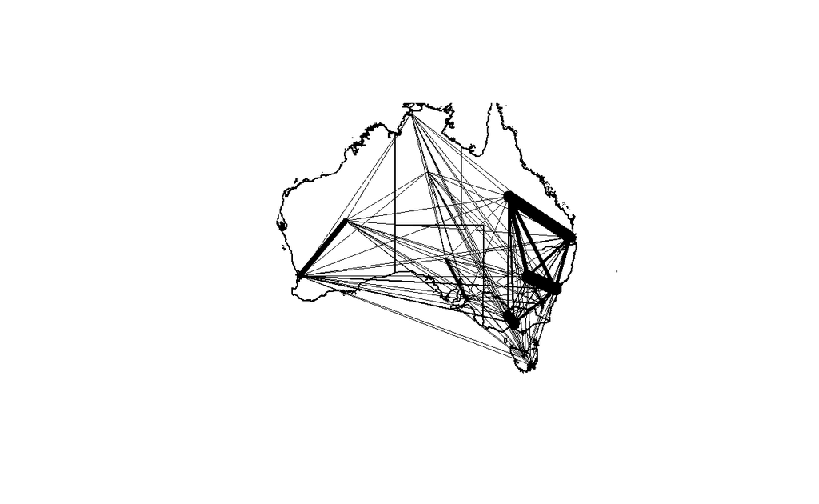

```r
plot(travel_networkwgs, lwd = w)
plot(AusWGS, add=T)
```

# 7. Building Spatial Interaction Models

It is time for us to learn how to using R Stat function to calibrate the Spatial Interaction Models. Instead of using lm() the glm() function will be used. This is because glm() allow us to calibrate the model using generalised linear regression methods.

Note: Section 2.2.2 of Modelling population flows using spatial interaction models provides a detail discussion of generalised linear regression modelling framework.

## 7.1 Unconstrained Spatial Interaction Model

In this section, we will calibrate an unconstrained spatial interaction model by using glm(). The explanatory variables are origin population (i.e. vi1_origpop), destination median income (i.e. wj3_destmedinc) and distance between origin and destination in km (i.e. dist).

```r
uncosim <- glm(Flow ~ log(vi1_origpop)+log(wj3_destmedinc)+log(dist), na.action = na.exclude, family = poisson(link = "log"), data = mdatasub)
summary(uncosim)
```

```
Call:
glm(formula = Flow ~ log(vi1_origpop) + log(wj3_destmedinc) +
    log(dist), family = poisson(link = "log"), data = mdatasub,
    na.action = na.exclude)

Deviance Residuals:
    Min       1Q   Median       3Q      Max
-177.78   -54.49   -24.50     9.21   470.11

Coefficients:
                      Estimate Std. Error z value Pr(>|z|)
(Intercept)          7.1953790  0.0248852  289.14   <2e-16 ***
log(vi1_origpop)     0.5903363  0.0009232  639.42   <2e-16 ***
log(wj3_destmedinc) -0.1671417  0.0033663  -49.65   <2e-16 ***
log(dist)           -0.8119316  0.0010157 -799.41   <2e-16 ***
---
Signif. codes:  0 '***' 0.001 '**' 0.01 '*' 0.05 '.' 0.1 ' ' 1

(Dispersion parameter for poisson family taken to be 1)

    Null deviance: 2750417  on 209  degrees of freedom
Residual deviance: 1503573  on 206  degrees of freedom
AIC: 1505580

Number of Fisher Scoring iterations: 5
```

The model output report shows that the parameter estimates of the explanatory variables are significant at alpha value 0.001.

### 7.1.1 Fitting the model

To assess the performance of the model, we will use the fitted() of R to compute the fitted values.

```r
mdatasub$fitted <- fitted(uncosim)
```

### 7.1.2 The more difficult ways (optional)

Another way to calculate the estimates is to plug all of the parameters back into Equation 6 like this:

First, assign the parameter values from the model to the appropriate variables

```r
k <- uncosim$coefficients[1]
mu <- uncosim$coefficients[2]
alpha <- uncosim$coefficients[3]
beta <- -uncosim$coefficients[4]
```

Next, plug everything back into the Equation 6 model… (be careful with the positive and negative signing of the parameters as the beta parameter may not have been saved as negative so will need to force negative)

```r
mdatasub$unconstrainedEst2 <- exp(k+(mu*log(mdatasub$vi1_origpop))+(alpha*log(mdatasub$wj3_destmedinc))-(beta*log(mdatasub$dist)))
```

which is exactly the same as this

```r
mdatasub$unconstrainedEst2 <- (exp(k)*exp(mu*log(mdatasub$vi1_origpop))*exp(alpha*log(mdatasub$wj3_destmedinc))*exp(-beta*log(mdatasub$dist)))
```

### 7.1.3 Saving the fitted values

Now, we will run the model and save all of the new flow estimates in a new column in the dataframe.

```r
mdatasub$unconstrainedEst2 <- round(mdatasub$unconstrainedEst2,0)
sum(mdatasub$unconstrainedEst2)
```

```
[1] 1313517
```

Next, we will turn the output into a little matrix by using dcast() of maditr package.

```r
mdatasubmat2 <- dcast(mdatasub, Orig_code ~ Dest_code, sum, value.var = "unconstrainedEst2", margins=c("Orig_code", "Dest_code"))
mdatasubmat2
```

```
   Orig_code 1GSYD  1RNSW  2GMEL  2RVIC 3GBRI 3RQLD 4GADE 4RSAU 5GPER
1      1GSYD     0  30810  20358  19562 17788 11282 13497 10525  5234
2      1RNSW 20638      0  15339  16316 12198  9789 12439  9661  4114
3      2GMEL 17285  19443      0  69923 10043  9071 19565 11595  5685
4      2RVIC  9053  11272  38111      0  5413  5035 12044  6686  3070
5      3GBRI 11364  11634   7556   7473     0  9436  6605  6097  3116
6      3RQLD  6931   8978   6563   6683  9074     0  7227  8378  3783
7      4GADE  5784   7958   9875  11153  4431  5042     0 10176  3464
8      4RSAU  2278   3122   2956   3127  2066  2952  5140     0  1878
9      5GPER  2986   3504   3820   3784  2782  3512  4611  4950     0
10     5RWAU  1583   1908   1947   1952  1534  2126  2446  3017  3885
11     6GHOB  2125   2081   3758   3099  1409  1257  2162  1507   919
12     6RTAS  2653   2642   5282   4230  1724  1549  2801  1894  1119
13     7GDAR   647    769    711    710   701  1102   815   981   736
14     7RNTE   678    841    756    765   726  1287   921  1241   713
```

[output cut: 19 more lines]

and compare with the original matrix by using the code chunk below.

```r
mdatasubmat <- dcast(mdatasub, Orig_code ~ Dest_code, sum, value.var = "Flow", margins=c("Orig_code", "Dest_code"))
mdatasubmat
```

```
   Orig_code  1GSYD  1RNSW  2GMEL  2RVIC  3GBRI  3RQLD 4GADE 4RSAU
1      1GSYD      0  91031  22601   4416  22888  27445  5817   795
2      1RNSW  53562      0  12407  13084  21300  35189  3617  1591
3      2GMEL  15560  11095      0  70260  13057  16156  6021  1300
4      2RVIC   2527  11967  48004      0   4333  10102  3461  2212
5      3GBRI  12343  16061  13078   4247      0  84649  3052   820
6      3RQLD  11634  26701  12284   7573  74410      0  3774  1751
7      4GADE   5421   3518   8810   3186   5447   6173     0 25677
8      4RSAU    477   1491   1149   2441    820   2633 22015     0
9      5GPER   6516   4066  11729   2929   5081   7006  2631   867
10     5RWAU    714   2242   1490   1813   1137   4328   807   982
11     6GHOB   1224   1000   3016    622   1307   1804   533   106
12     6RTAS   1024   1866   2639   1636   1543   2883   651   342
13     7GDAR   1238   2178   1953   1480   2769   5108  2105   641
14     7RNTE    406   1432    700    792    896   3018  1296   961
```

[output cut: 19 more lines]

We can also visualise the actual flow and estimated flow by scatter plot technique.

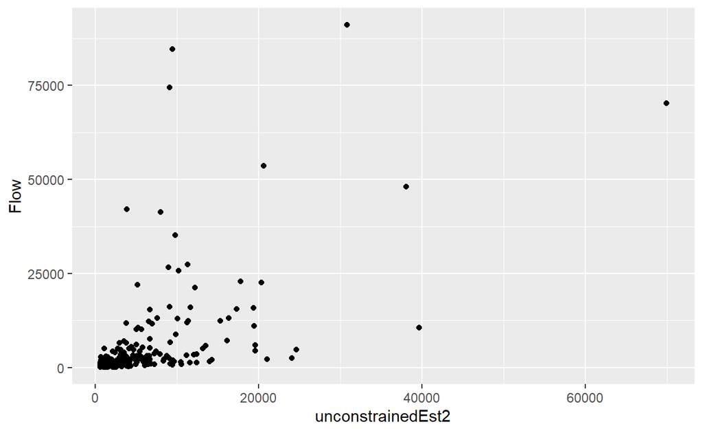

```r
ggplot(data=mdatasub,
       aes(y = `Flow`,
           x = `unconstrainedEst2`))+
  geom_point(color="black", fill="light blue")
```

### 7.1.4 Assessing the model performance

To provide a more formal assessment of the model, Goodness-o-Fit statistics will be used. The code chunk below uses postReSample() of caret package to compute three Goodness-of-Fit statistics.

```r
postResample(mdatasub$Flow,mdatasub$unconstrainedEst2)
```

```
        RMSE     Rsquared          MAE
1.078917e+04 3.245418e-01 5.054548e+03
```

Notice that the R-squared value of 0.32 is relatively low. It seems that the uncontrained model failed to fit the empirical data well.

## 7.2 Origin Constrained Spatial Interaction Model

In this section, we will calibrate an origin constrained SIM (the “-1” indicates no intercept in the regression model) by using glm().

```r
origSim <- glm(Flow ~ Orig_code+log(wj3_destmedinc)+log(dist)-1, na.action = na.exclude, family = poisson(link = "log"), data = mdatasub)
#let's have a look at it's summary...
summary(origSim)
```

```
Call:
glm(formula = Flow ~ Orig_code + log(wj3_destmedinc) + log(dist) -
    1, family = poisson(link = "log"), data = mdatasub, na.action = na.exclude)

Deviance Residuals:
    Min       1Q   Median       3Q      Max
-225.71   -54.10   -15.94    20.45   374.27

Coefficients:
                     Estimate Std. Error z value Pr(>|z|)
Orig_code1GSYD      19.541851   0.023767  822.22   <2e-16 ***
Orig_code1RNSW      19.425497   0.023913  812.35   <2e-16 ***
Orig_code2GMEL      18.875763   0.023243  812.12   <2e-16 ***
Orig_code2RVIC      18.335242   0.022996  797.31   <2e-16 ***
Orig_code3GBRI      19.856564   0.024063  825.20   <2e-16 ***
Orig_code3RQLD      20.094898   0.024300  826.94   <2e-16 ***
Orig_code4GADE      18.747938   0.023966  782.28   <2e-16 ***
Orig_code4RSAU      18.324029   0.024407  750.75   <2e-16 ***
Orig_code5GPER      20.010551   0.024631  812.43   <2e-16 ***
Orig_code5RWAU      19.392751   0.024611  787.96   <2e-16 ***
Orig_code6GHOB      16.802016   0.024282  691.97   <2e-16 ***
Orig_code6RTAS      17.013981   0.023587  721.33   <2e-16 ***
Orig_code7GDAR      18.607483   0.025012  743.93   <2e-16 ***
Orig_code7RNTE      17.798856   0.025704  692.45   <2e-16 ***
Orig_code8ACTE      17.796693   0.023895  744.79   <2e-16 ***
log(wj3_destmedinc) -0.272640   0.003383  -80.59   <2e-16 ***
log(dist)           -1.227679   0.001400 -876.71   <2e-16 ***
---
Signif. codes:  0 '***' 0.001 '**' 0.01 '*' 0.05 '.' 0.1 ' ' 1

(Dispersion parameter for poisson family taken to be 1)

    Null deviance: 23087017  on 210  degrees of freedom
Residual deviance:  1207394  on 193  degrees of freedom
AIC: 1209427

Number of Fisher Scoring iterations: 6
```

We can examine how the constraints hold for destinations this time.

Firstly, we will fitted the model and roundup the estimated values by using the code chunk below.

```r
mdatasub$origSimFitted <- round(fitted(origSim),0)
```

Next, we will used the step you had learned in previous section to create pivot table to turn paired list into matrix.

```r
mdatasubmat3 <- dcast(mdatasub, Orig_code ~ Dest_code, sum, value.var = "origSimFitted", margins=c("Orig_code", "Dest_code"))
mdatasubmat3
```

```
   Orig_code  1GSYD  1RNSW  2GMEL  2RVIC 3GBRI 3RQLD 4GADE 4RSAU
1      1GSYD      0  36794  19752  18516 15905  8076 10591  7248
2      1RNSW  29163      0  18862  20620 13173  9548 13715  9329
3      2GMEL   8501  10243      0  70950  3742  3243 10367  4685
4      2RVIC   4924   6918  43838      0  2263  2050  7667  3139
5      3GBRI  21684  22658  11852  11604     0 16555  9653  8526
6      3RQLD  12057  17984  11248  11511 18128     0 12989 16188
7      4GADE   4109   6714   9345  11186  2747  3376     0  9731
8      4RSAU   1922   3122   2887   3130  1659  2876  6653     0
9      5GPER   3930   5048   5777   5673  3533  5080  7666  8507
10     5RWAU   2445   3269   3387   3386  2333  3862  4775  6535
11     6GHOB    619    605   1485   1105   333   283   643   371
12     6RTAS    827    829   2374   1689   431   371   908   501
13     7GDAR   1030   1350   1204   1198  1165  2331  1478  1948
14     7RNTE    644    899    769    779   714  1716  1034  1618
```

[output cut: 19 more lines]

You can then compare with the original observed data as shown below.

```r
mdatasubmat
```

```
   Orig_code  1GSYD  1RNSW  2GMEL  2RVIC  3GBRI  3RQLD 4GADE 4RSAU
1      1GSYD      0  91031  22601   4416  22888  27445  5817   795
2      1RNSW  53562      0  12407  13084  21300  35189  3617  1591
3      2GMEL  15560  11095      0  70260  13057  16156  6021  1300
4      2RVIC   2527  11967  48004      0   4333  10102  3461  2212
5      3GBRI  12343  16061  13078   4247      0  84649  3052   820
6      3RQLD  11634  26701  12284   7573  74410      0  3774  1751
7      4GADE   5421   3518   8810   3186   5447   6173     0 25677
8      4RSAU    477   1491   1149   2441    820   2633 22015     0
9      5GPER   6516   4066  11729   2929   5081   7006  2631   867
10     5RWAU    714   2242   1490   1813   1137   4328   807   982
11     6GHOB   1224   1000   3016    622   1307   1804   533   106
12     6RTAS   1024   1866   2639   1636   1543   2883   651   342
13     7GDAR   1238   2178   1953   1480   2769   5108  2105   641
14     7RNTE    406   1432    700    792    896   3018  1296   961
```

[output cut: 19 more lines]

Next, let us display the actual flow and estimated flow by using the scatter plot technique.

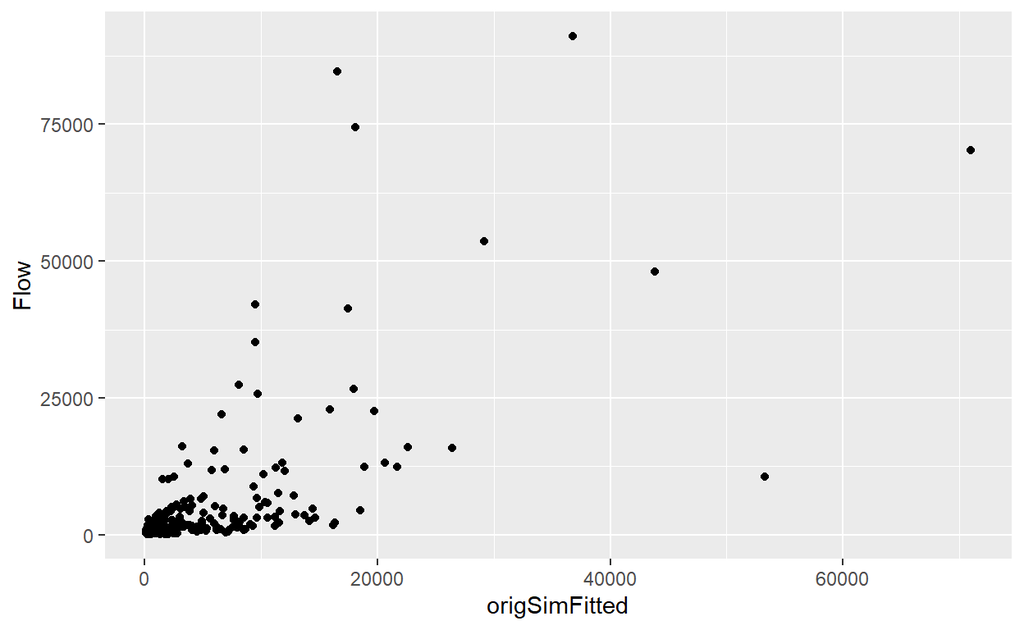

```r
ggplot(data=mdatasub,
       aes(y = `Flow`,
           x = `origSimFitted`))+
  geom_point(color="black", fill="light blue")
```

Lastly, we compare the fitted values and the actual values by computing Goodness-of-fit statistics

```r
postResample(mdatasub$Flow,mdatasub$origSimFitted)
```

```
        RMSE     Rsquared          MAE
9872.6934321    0.4345011 4804.6714286
```

Notice that the R-squared improved considerably from 0.32 in the unconstrained model to 0.43 in this origin constrained model.

## 7.3 Destination Constrained Spatial Interaction Model

In this section, we will calibrate a destination constrained SIM (the “-1” indicates no intercept in the regression model) by using glm().

```r
destSim <- glm(Flow ~ Dest_code+log(vi1_origpop)+log(dist)-1, na.action = na.exclude, family = poisson(link = "log"), data = mdatasub)
summary(destSim)
```

```
Call:
glm(formula = Flow ~ Dest_code + log(vi1_origpop) + log(dist) -
    1, family = poisson(link = "log"), data = mdatasub, na.action = na.exclude)

Deviance Residuals:
    Min       1Q   Median       3Q      Max
-138.69   -33.38   -10.47    11.72   293.39

Coefficients:
                   Estimate Std. Error z value Pr(>|z|)
Dest_code1GSYD    8.8262922  0.0176638   499.7   <2e-16 ***
Dest_code1RNSW    9.1809447  0.0178316   514.9   <2e-16 ***
Dest_code2GMEL    8.6716196  0.0170155   509.6   <2e-16 ***
Dest_code2RVIC    8.0861927  0.0173840   465.1   <2e-16 ***
Dest_code3GBRI    9.5462594  0.0183631   519.9   <2e-16 ***
Dest_code3RQLD   10.1295722  0.0184672   548.5   <2e-16 ***
Dest_code4GADE    8.3051406  0.0184018   451.3   <2e-16 ***
Dest_code4RSAU    8.1438651  0.0188772   431.4   <2e-16 ***
Dest_code5GPER    9.9664486  0.0190008   524.5   <2e-16 ***
Dest_code5RWAU    9.3061908  0.0190006   489.8   <2e-16 ***
Dest_code6GHOB    6.9737562  0.0186288   374.4   <2e-16 ***
Dest_code6RTAS    7.1546249  0.0183673   389.5   <2e-16 ***
Dest_code7GDAR    8.3972440  0.0199735   420.4   <2e-16 ***
Dest_code7RNTE    7.4521232  0.0206128   361.5   <2e-16 ***
Dest_code8ACTE    7.3585270  0.0181823   404.7   <2e-16 ***
log(vi1_origpop)  0.5828662  0.0009556   610.0   <2e-16 ***
log(dist)        -1.1820013  0.0015267  -774.2   <2e-16 ***
---
Signif. codes:  0 '***' 0.001 '**' 0.01 '*' 0.05 '.' 0.1 ' ' 1

(Dispersion parameter for poisson family taken to be 1)

    Null deviance: 23087017  on 210  degrees of freedom
Residual deviance:   665984  on 193  degrees of freedom
AIC: 668017

Number of Fisher Scoring iterations: 5
```

We can examine how the constraints hold for destinations this time. Firstly, we will fitted the model and roundup the estimated values by using the code chunk below.

```r
mdatasub$destSimFitted <- round(fitted(destSim),0)
```

Next, we will used the step you had learned in previous section to create pivot table to turn paired list into matrix.

```r
mdatasubmat6 <- dcast(mdatasub, Orig_code ~ Dest_code, sum, value.var = "destSimFitted", margins=c("Orig_code", "Dest_code"))
mdatasubmat6
```

```
   Orig_code  1GSYD  1RNSW  2GMEL  2RVIC  3GBRI  3RQLD 4GADE 4RSAU
1      1GSYD      0  62297  19396  10743  44563  36077  7551  4651
2      1RNSW  31560      0  14989   9626  30026  34242  7824  4791
3      2GMEL  21440  32707      0  70421  19896  26950 13303  5496
4      2RVIC  11302  19990  67018      0  10936  15458  8873  3332
5      3GBRI  13977  18589   5645   3260      0  34266  3286  2588
6      3RQLD   6643  12446   4489   2705  20116      0  3658  4013
7      4GADE   6042  12358   9630   6749   8385  15896     0  6304
8      4RSAU   2170   4413   2320   1478   3851  10169  3676     0
9      5GPER   2098   3404   2196   1272   3872   8540  2046  2007
10     5RWAU   1172   1977   1159    683   2291   5786  1144  1374
11     6GHOB   2286   2850   3834   1700   2571   3421  1214   635
12     6RTAS   2914   3724   5810   2468   3184   4278  1635   818
13     7GDAR    472    782    397    233   1088   3298   343   397
14     7RNTE    550    967    471    281   1243   4494   445   608
```

[output cut: 19 more lines]

Similar to the previous section, you can then compare with the original observed data as shown below.

```r
mdatasubmat
```

```
   Orig_code  1GSYD  1RNSW  2GMEL  2RVIC  3GBRI  3RQLD 4GADE 4RSAU
1      1GSYD      0  91031  22601   4416  22888  27445  5817   795
2      1RNSW  53562      0  12407  13084  21300  35189  3617  1591
3      2GMEL  15560  11095      0  70260  13057  16156  6021  1300
4      2RVIC   2527  11967  48004      0   4333  10102  3461  2212
5      3GBRI  12343  16061  13078   4247      0  84649  3052   820
6      3RQLD  11634  26701  12284   7573  74410      0  3774  1751
7      4GADE   5421   3518   8810   3186   5447   6173     0 25677
8      4RSAU    477   1491   1149   2441    820   2633 22015     0
9      5GPER   6516   4066  11729   2929   5081   7006  2631   867
10     5RWAU    714   2242   1490   1813   1137   4328   807   982
11     6GHOB   1224   1000   3016    622   1307   1804   533   106
12     6RTAS   1024   1866   2639   1636   1543   2883   651   342
13     7GDAR   1238   2178   1953   1480   2769   5108  2105   641
14     7RNTE    406   1432    700    792    896   3018  1296   961
```

[output cut: 19 more lines]

Next, let us display the actual flow and estimated flow by using the scatter plot technique.

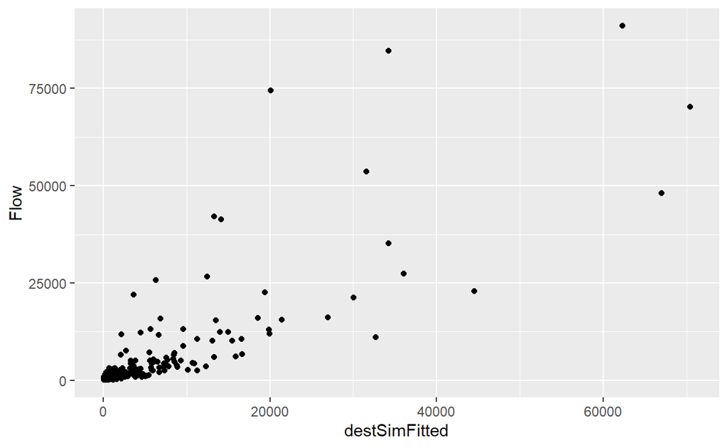

```r
ggplot(data=mdatasub,
       aes(y = `Flow`,
           x = `destSimFitted`))+
  geom_point(color="black", fill="light blue")
```

Finally, we can test the Goodness-of-Fit in exactly the same way as before:

```r
postResample(mdatasub$Flow,mdatasub$destSimFitted)
```

```
        RMSE     Rsquared          MAE
7714.6272042    0.6550357 3445.6619048
```

## 7.4 Doubly Constrained Spatial Interaction Model

In this section, we will calibrate a Doubly Constrained Spatial Interaction Model by using glm().

```r
doubSim <- glm(Flow ~ Orig_code+Dest_code+log(dist), na.action = na.exclude, family = poisson(link = "log"), data = mdatasub)
summary(doubSim)
```

```
Call:
glm(formula = Flow ~ Orig_code + Dest_code + log(dist), family = poisson(link = "log"),
    data = mdatasub, na.action = na.exclude)

Deviance Residuals:
    Min       1Q   Median       3Q      Max
-93.018  -26.703    0.021   19.046  184.179

Coefficients:
                Estimate Std. Error  z value Pr(>|z|)
(Intercept)    20.208178   0.011308 1786.999   <2e-16 ***
Orig_code1RNSW -0.122417   0.003463  -35.353   <2e-16 ***
Orig_code2GMEL -0.455872   0.003741 -121.852   <2e-16 ***
Orig_code2RVIC -1.434386   0.004511 -317.969   <2e-16 ***
Orig_code3GBRI  0.241303   0.003597   67.091   <2e-16 ***
Orig_code3RQLD  0.772753   0.003599  214.700   <2e-16 ***
Orig_code4GADE -0.674261   0.004527 -148.936   <2e-16 ***
Orig_code4RSAU -1.248974   0.005889 -212.091   <2e-16 ***
Orig_code5GPER  0.742687   0.004668  159.118   <2e-16 ***
Orig_code5RWAU -0.317806   0.005131  -61.943   <2e-16 ***
Orig_code6GHOB -2.270736   0.008576 -264.767   <2e-16 ***
Orig_code6RTAS -1.988784   0.007477 -265.981   <2e-16 ***
Orig_code7GDAR -0.797620   0.007089 -112.513   <2e-16 ***
Orig_code7RNTE -1.893522   0.008806 -215.022   <2e-16 ***
Orig_code8ACTE -1.921309   0.005511 -348.631   <2e-16 ***
Dest_code1RNSW  0.389478   0.003899   99.894   <2e-16 ***
Dest_code2GMEL -0.007616   0.004244   -1.794   0.0727 .
Dest_code2RVIC -0.781258   0.004654 -167.854   <2e-16 ***
Dest_code3GBRI  0.795909   0.004037  197.178   <2e-16 ***
Dest_code3RQLD  1.516186   0.003918  386.955   <2e-16 ***
Dest_code4GADE -0.331189   0.005232  -63.304   <2e-16 ***
Dest_code4RSAU -0.627202   0.006032 -103.980   <2e-16 ***
Dest_code5GPER  1.390114   0.005022  276.811   <2e-16 ***
Dest_code5RWAU  0.367314   0.005362   68.509   <2e-16 ***
Dest_code6GHOB -1.685934   0.008478 -198.859   <2e-16 ***
Dest_code6RTAS -1.454819   0.007612 -191.112   <2e-16 ***
Dest_code7GDAR -0.308516   0.007716  -39.986   <2e-16 ***
Dest_code7RNTE -1.462020   0.009743 -150.060   <2e-16 ***
Dest_code8ACTE -1.506283   0.005709 -263.866   <2e-16 ***
log(dist)      -1.589102   0.001685 -942.842   <2e-16 ***
---
Signif. codes:  0 '***' 0.001 '**' 0.01 '*' 0.05 '.' 0.1 ' ' 1

(Dispersion parameter for poisson family taken to be 1)

    Null deviance: 2750417  on 209  degrees of freedom
Residual deviance:  335759  on 180  degrees of freedom
AIC: 337818

Number of Fisher Scoring iterations: 6
```

We can examine how the constraints hold for destinations this time. Firstly, we will fitted the model and roundup the estimated values by using the code chunk below.

```r
mdatasub$doubsimFitted <- round(fitted(doubSim),0)
```

Next, we will used the step you had learned in previous section to create pivot table to turn paired list into matrix.

```r
mdatasubmat7 <- dcast(mdatasub, Orig_code ~ Dest_code, sum, value.var = "doubsimFitted", margins=c("Orig_code", "Dest_code"))
mdatasubmat7
```

```
   Orig_code  1GSYD  1RNSW  2GMEL  2RVIC  3GBRI  3RQLD 4GADE 4RSAU
1      1GSYD      0  66903  18581   8510  39179  27666  6190  2981
2      1RNSW  40099      0  18006  10062  31574  35342  8897  4252
3      2GMEL  11868  19189      0  72706   9037  12748  9040  2545
4      2RVIC   4429   8737  59237      0   3567   5329  4629  1146
5      3GBRI  22501  30254   8125   3937      0  59334  4650  3116
6      3RQLD  13155  28037   9490   4869  49124      0  8534  8930
7      4GADE   4392  10534  10043   6311   5745  12736     0  6216
8      4RSAU   1601   3809   2139   1183   2914  10085  4704     0
9      5GPER   3336   5860   4336   2109   6404  17395  4668  4203
10     5RWAU   1390   2573   1673    833   2883   9398  1948  2302
11     6GHOB    954   1176   2336    793    940   1295   589   228
12     6RTAS   1398   1781   4318   1384   1326   1850   929   339
13     7GDAR    776   1401    751    371   2007   8361   730   822
14     7RNTE    403    788    400    202   1014   5356   438   615
```

[output cut: 19 more lines]

Similar to the previous section, you can then compare with the original observed data as shown below.

```r
mdatasubmat
```

```
   Orig_code  1GSYD  1RNSW  2GMEL  2RVIC  3GBRI  3RQLD 4GADE 4RSAU
1      1GSYD      0  91031  22601   4416  22888  27445  5817   795
2      1RNSW  53562      0  12407  13084  21300  35189  3617  1591
3      2GMEL  15560  11095      0  70260  13057  16156  6021  1300
4      2RVIC   2527  11967  48004      0   4333  10102  3461  2212
5      3GBRI  12343  16061  13078   4247      0  84649  3052   820
6      3RQLD  11634  26701  12284   7573  74410      0  3774  1751
7      4GADE   5421   3518   8810   3186   5447   6173     0 25677
8      4RSAU    477   1491   1149   2441    820   2633 22015     0
9      5GPER   6516   4066  11729   2929   5081   7006  2631   867
10     5RWAU    714   2242   1490   1813   1137   4328   807   982
11     6GHOB   1224   1000   3016    622   1307   1804   533   106
12     6RTAS   1024   1866   2639   1636   1543   2883   651   342
13     7GDAR   1238   2178   1953   1480   2769   5108  2105   641
14     7RNTE    406   1432    700    792    896   3018  1296   961
```

[output cut: 19 more lines]

Next, let us display the actual flow and estimated flow by using the scatter plot technique.

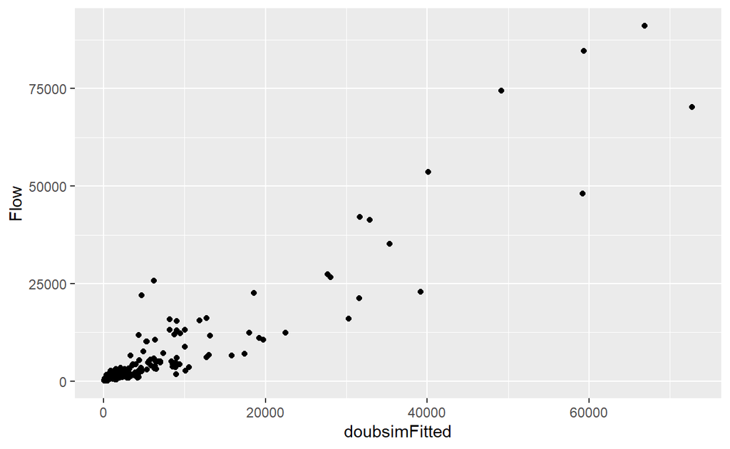

```r
ggplot(data=mdatasub,
       aes(y = `Flow`,
           x = `doubsimFitted`))+
  geom_point(color="black", fill="light blue")
```

The scatter plot above reveals that the fitted values are highly correlated with the actual flow values. This show the Doubly Constrained Spatial Interaction Model is the best fit model among the four spatial interaction models.

To provide a quantitative assessment of the model, we can compute the Goodness-of-fit statistics exactly the same way as before.

```r
postResample(mdatasub$Flow,mdatasub$doubsimFitted)
```

```
        RMSE     Rsquared          MAE
4877.7989865    0.8662571 2462.6761905
```

The Goodness-of-fit statistics reveal that the Doubly Constrained Spatial Interaction Model is the best model because it produces the best R-squared statistic and smallest RMSE.